# Topic Modeling Amazon Fine Food Reviews

I use 20,000 Amazon food reviews from the [Amazon Fine Food Reviews dataset](https://www.kaggle.com/datasets/snap/amazon-fine-food-reviews) (Kaggle) to find the main themes people write about, without any labels telling me what those themes are.

I compare three unsupervised approaches on the same data:

1. **PCA** on the TF-IDF matrix, to see how much structure a small number of components can capture
2. **Truncated SVD (latent semantic analysis)**, which handles sparse text matrices directly
3. **NMF and LDA**, two standard topic models, compared head to head

## Setup

Everything here is pandas, scikit-learn, and matplotlib. The dataset file `Reviews.csv` comes from Kaggle and isn't committed to the repo because of its size.

```python
import pandas as pd
import numpy as np
import re
import matplotlib.pyplot as plt

from sklearn.feature_extraction.text import TfidfVectorizer, CountVectorizer
from sklearn.decomposition import PCA, TruncatedSVD, NMF, LatentDirichletAllocation
from sklearn.preprocessing import Normalizer
from sklearn.pipeline import make_pipeline

import warnings
warnings.filterwarnings('ignore')
```

## Data and text cleaning

I keep the first 20,000 reviews to keep runtimes reasonable and drop any rows with missing text. The cleaning function lowercases everything, strips out non-letter characters, and drops tokens of two characters or fewer. That last step also happens to remove `br` fragments left over from `<br>` HTML tags in the raw reviews, which would otherwise show up as a fake "topic" later on.

```python
df = pd.read_csv('Reviews.csv', nrows=20000)
df = df.dropna(subset=['Text'])
df = df.reset_index(drop=True)

print(f"Dataset shape: {df.shape}")
print(f"Sample review:\n{df['Text'].iloc[0][:200]}")
```

```
Dataset shape: (20000, 10)
Sample review:
I have bought several of the Vitality canned dog food products and have found them all to be of good quality. The product looks more like a stew than a processed meat and it smells better. My Labrador
```

```python
def preprocess_text(text):
    text = text.lower()
    text = re.sub(r'[^a-z\s]', ' ', text)
    text = re.sub(r'\s+', ' ', text).strip()
    tokens = [t for t in text.split() if len(t) > 2]
    return ' '.join(tokens)

df['clean_text'] = df['Text'].apply(preprocess_text)

print("Preprocessing complete.")
print(f"Sample cleaned review:\n{df['clean_text'].iloc[0][:200]}")
```

```
Preprocessing complete.
Sample cleaned review:
have bought several the vitality canned dog food products and have found them all good quality the product looks more like stew than processed meat and smells better labrador finicky and she appreciat
```

## TF-IDF representation

TF-IDF weights each word by how often it appears in a review, discounted by how common it is across all reviews. Words like "coffee" get high weights in coffee reviews, while filler words that show up everywhere get pushed down. I cap the vocabulary at 5,000 terms for the PCA section (PCA needs a dense matrix, so memory is the constraint) and use `sublinear_tf` so a word appearing 20 times doesn't count 20x as much as one appearance.

```python
tfidf_vectorizer = TfidfVectorizer(
    stop_words='english',
    max_features=5000,
    min_df=2,
    max_df=0.95,
    sublinear_tf=True)

tfidf_matrix = tfidf_vectorizer.fit_transform(df['clean_text'])
feature_names = np.array(tfidf_vectorizer.get_feature_names_out())

print(f"TF-IDF matrix shape: {tfidf_matrix.shape}")
print(f"  {tfidf_matrix.shape[0]} documents x {tfidf_matrix.shape[1]} terms")
```

```
TF-IDF matrix shape: (20000, 5000)
  20000 documents x 5000 terms
```

## Part 1: PCA on the review matrix

First question: if I compress 5,000 word dimensions down to 10 components, how much of the variation in the reviews do those components actually capture? PCA finds the directions of maximum variance, so the answer tells me how concentrated the structure in this text is.

```python
tfidf_dense = tfidf_matrix.toarray()

pca = PCA(n_components=10, random_state=42)
pca_result = pca.fit_transform(tfidf_dense)

print(f"PCA result shape: {pca_result.shape}")
```

```
PCA result shape: (20000, 10)
```

```python
# Eigenvalues of the covariance matrix, sorted largest to smallest
cov_matrix = np.cov(pca_result.T)
eigenvalues, eigenvectors = np.linalg.eig(cov_matrix)

sorted_idx = np.argsort(eigenvalues)[::-1]
eigenvalues_sorted  = eigenvalues[sorted_idx].real
eigenvectors_sorted = eigenvectors[:, sorted_idx].real

print("Sorted Eigenvalues (descending):")
for i, ev in enumerate(eigenvalues_sorted):
    print(f"  PC{i+1}: {ev:.6f}")
```

```
Sorted Eigenvalues (descending):
  PC1: 0.008388
  PC2: 0.005604
  PC3: 0.004820
  PC4: 0.004615
  PC5: 0.003973
  PC6: 0.003686
  PC7: 0.003567
  PC8: 0.003323
  PC9: 0.003256
  PC10: 0.003196
```

```
Explained Variance per Principal Component:
PC       Explained Var   Cumulative
-----------------------------------
PC1           0.8572%     0.8572%
PC2           0.5726%     1.4298%
PC3           0.4925%     1.9223%
PC4           0.4716%     2.3939%
PC5           0.4060%     2.7999%
PC6           0.3767%     3.1765%
PC7           0.3645%     3.5411%
PC8           0.3395%     3.8806%
PC9           0.3327%     4.2133%
PC10          0.3266%     4.5399%
```

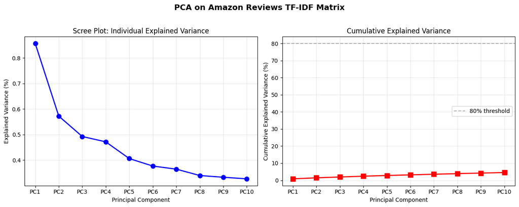

```python
explained_variance_ratio = pca.explained_variance_ratio_
cumulative_variance      = np.cumsum(explained_variance_ratio)

print("Explained Variance per Principal Component:")
print(f"{'PC':<6} {'Explained Var':>15} {'Cumulative':>12}")
print("-" * 35)
for i, (ev, cv) in enumerate(zip(explained_variance_ratio, cumulative_variance)):
    print(f"PC{i+1:<4} {ev:>14.4%} {cv:>11.4%}")

pc_labels = [f'PC{i+1}' for i in range(10)]

fig, axes = plt.subplots(1, 2, figsize=(13, 5))

axes[0].plot(pc_labels, explained_variance_ratio * 100, 'bo-', linewidth=2, markersize=8)
axes[0].set_title('Scree Plot: Individual Explained Variance')
axes[0].set_xlabel('Principal Component')
axes[0].set_ylabel('Explained Variance (%)')
axes[0].grid(True, alpha=0.3)

axes[1].plot(pc_labels, cumulative_variance * 100, 'rs-', linewidth=2, markersize=8)
axes[1].axhline(y=80, color='gray', linestyle='--', alpha=0.6, label='80% threshold')
axes[1].set_title('Cumulative Explained Variance')
axes[1].set_xlabel('Principal Component')
axes[1].set_ylabel('Cumulative Explained Variance (%)')
axes[1].legend()
axes[1].grid(True, alpha=0.3)

plt.suptitle('PCA on Amazon Reviews TF-IDF Matrix', y=1.02, fontsize=14, fontweight='bold')
plt.tight_layout()
plt.show()
```

Each component explains under 1% of total variance, and the first 10 together cover only about 4.5%. That sounds bad but it's normal for text: a TF-IDF matrix is extremely sparse and high dimensional, so variance is spread thin across thousands of word directions. The scree plot still shows the usual elbow shape, meaning the first few components carry the most interpretable structure. What matters is what those components mean, which is next.

```python
# Top terms per principal component
n_top_terms = 10
components  = pca.components_

print(f"Top {n_top_terms} terms per Principal Component:\n")
print("=" * 55)
for pc_idx in range(pca.n_components_):
    top_indices = np.argsort(np.abs(components[pc_idx]))[::-1][:n_top_terms]
    top_terms   = feature_names[top_indices]
    top_weights = components[pc_idx][top_indices]
    print(f"\nPC{pc_idx+1} (explains {explained_variance_ratio[pc_idx]:.2%} of variance):")
    for term, weight in zip(top_terms, top_weights):
        print(f"  {term:<20} loading: {weight:+.4f}")
```

```
Top 10 terms per Principal Component:

=======================================================

PC1 (explains 0.86% of variance):
  coffee               loading: +0.6818
  cup                  loading: +0.2864
  cups                 loading: +0.1616
  strong               loading: +0.1485
  dog                  loading: -0.1354
  bold                 loading: +0.1287
  food                 loading: -0.1286
  blend                loading: +0.1212
  keurig               loading: +0.1168
  flavor               loading: +0.1156

PC2 (explains 0.57% of variance):
  dog                  loading: +0.2666
  tea                  loading: -0.2290
  taste                loading: -0.2197
  drink                loading: -0.2114
  coffee               loading: +0.2088
  treats               loading: +0.1975
  juice                loading: -0.1895
  sugar                loading: -0.1824
  flavor               loading: -0.1760
  like                 loading: -0.1759

PC3 (explains 0.49% of variance):
  tea                  loading: +0.7299
  coffee               loading: -0.1640
  like                 loading: -0.1620
  dog                  loading: -0.1286
  treats               loading: -0.1031
  teas                 loading: +0.1011
  taste                loading: -0.1006
  amazon               loading: +0.0972
  juice                loading: -0.0965
  grey                 loading: +0.0963

```

[output cut: 68 more lines]

```
  really               loading: -0.1525
  product              loading: -0.1371
  cocoa                loading: -0.1274

PC10 (explains 0.33% of variance):
  chocolate            loading: +0.3643
  price                loading: +0.2889
  best                 loading: +0.2618
  hot                  loading: +0.2166
  butter               loading: -0.2139
  peanut               loading: -0.2122
  amazon               loading: +0.1878
  good                 loading: +0.1717
  use                  loading: -0.1697
  free                 loading: +0.1504
```

The components are readable even with tiny variance shares. PC1 is basically a coffee axis (coffee, cup, strong, bold load positive; dog and food load negative), so it separates coffee reviews from pet food reviews. PC2 splits pet products from drinks like tea and juice. Signed loadings are useful here: a component isn't just a topic, it's a contrast between two kinds of reviews.

## Part 2: Latent semantic analysis with Truncated SVD

Truncated SVD does the same kind of dimensionality reduction as PCA but works on the sparse matrix directly, so I can afford a bigger vocabulary (10,000 terms). Applied to TF-IDF this is latent semantic analysis. I normalize the output vectors, which is the standard LSA pipeline in scikit-learn.

```python
svd_tfidf_vectorizer = TfidfVectorizer(
    stop_words='english',
    min_df=2,
    max_df=0.80,
    max_features=10000,
    sublinear_tf=True)

svd_tfidf_matrix = svd_tfidf_vectorizer.fit_transform(df['clean_text'])
svd_vocab = np.array(svd_tfidf_vectorizer.get_feature_names_out())

print(f"TF-IDF matrix shape for SVD: {svd_tfidf_matrix.shape}")
```

```
TF-IDF matrix shape for SVD: (20000, 10000)
```

```python
n_components = 5

svd_model    = TruncatedSVD(n_components=n_components, random_state=42)
normalizer   = Normalizer(copy=False)
lsa_pipeline = make_pipeline(svd_model, normalizer)

lsa_matrix = lsa_pipeline.fit_transform(svd_tfidf_matrix)

print(f"SVD n_components = {n_components}")
print(f"LSA matrix shape: {lsa_matrix.shape}")
```

```
SVD n_components = 5
LSA matrix shape: (20000, 5)
```

```python
n_top_words = 10

print(f"Top {n_top_words} words per SVD topic (n_components={n_components}):\n")
print("=" * 55)
for topic_idx, topic_vec in enumerate(svd_model.components_):
    top_word_indices = topic_vec.argsort()[::-1][:n_top_words]
    top_words = svd_vocab[top_word_indices]
    print(f"\nTopic {topic_idx + 1}:")
    print("  " + ' | '.join(top_words))
```

```
Top 10 words per SVD topic (n_components=5):

=======================================================

Topic 1:
  coffee | like | good | great | taste | flavor | just | product | love | really

Topic 2:
  coffee | cup | cups | strong | bold | blend | keurig | smooth | roast | bitter

Topic 3:
  dog | treats | food | dogs | coffee | loves | amazon | price | product | treat

Topic 4:
  tea | product | amazon | price | great | teas | grey | earl | loose | green

Topic 5:
  dog | tea | treats | dogs | food | drink | treat | juice | loves | like
```

SVD recovers the same broad themes: a generic sentiment topic (like, good, great), coffee, pet food, and tea. The downside is bleed-through. Because SVD components can mix signs and aren't constrained to be non-negative, words like "coffee" leak into the pet food topic. That's the main motivation for trying NMF next.

## Part 3: NMF topic modeling

Non-negative matrix factorization adds one constraint: every weight has to be zero or positive. No cancellation between words means each topic is a straight additive bundle of terms, which usually reads much cleaner than SVD components. I run it on the same 10,000-term TF-IDF matrix with 5 topics.

```python
num_topics  = 5
n_top_words = 10

nmf = NMF(n_components=num_topics, random_state=42)
X_nmf = nmf.fit_transform(svd_tfidf_matrix)

print("=== NMF Topics ===")
for i, topic in enumerate(nmf.components_):
    top_idx = topic.argsort()[:-n_top_words - 1:-1]
    top_words = [svd_vocab[idx] for idx in top_idx]
    print(f"NMF Topic {i+1}: {', '.join(top_words)}")
```

```
=== NMF Topics ===
NMF Topic 1: great, product, good, love, just, price, amazon, like, buy, taste
NMF Topic 2: coffee, cup, cups, strong, bold, blend, flavor, keurig, roast, smooth
NMF Topic 3: drink, juice, sugar, soda, like, taste, sweet, orange, switch, flavor
NMF Topic 4: tea, teas, grey, green, earl, loose, iced, love, bags, flavor
NMF Topic 5: dog, treats, food, dogs, loves, treat, eat, old, cat, love
```

These are the cleanest topics in the notebook. Coffee, tea, pet treats, and drinks each get their own coherent cluster, and the leftover topic collects generic review language (like, good, great, taste). If I had to hand these to a product team, this is the output I'd use.

## Part 4: LDA topic modeling

LDA is a probabilistic model: it treats each review as a mix of topics and each topic as a distribution over words. It's built on word counts rather than TF-IDF weights, so I switch to a CountVectorizer with the same vocabulary settings for a fair comparison.

```python
count_vectorizer = CountVectorizer(
    stop_words='english',
    min_df=2,
    max_df=0.80,
    max_features=10000)

count_matrix = count_vectorizer.fit_transform(df['clean_text'])
count_vocab  = np.array(count_vectorizer.get_feature_names_out())

lda = LatentDirichletAllocation(n_components=num_topics, random_state=42)
X_lda = lda.fit_transform(count_matrix)

print("=== LDA Topics ===")
for i, topic in enumerate(lda.components_):
    top_idx = topic.argsort()[:-n_top_words - 1:-1]
    top_words = [count_vocab[idx] for idx in top_idx]
    print(f"LDA Topic {i+1}: {', '.join(top_words)}")
```

```
=== LDA Topics ===
LDA Topic 1: like, good, great, just, taste, chips, flavor, love, butter, product
LDA Topic 2: food, dog, treats, like, dogs, product, just, good, love, eat
LDA Topic 3: tea, product, free, amazon, like, gluten, cookies, taste, good, great
LDA Topic 4: coffee, cup, like, good, great, flavor, taste, just, cups, price
LDA Topic 5: like, taste, sugar, drink, flavor, juice, sweet, good, soda, just
```

LDA finds the same underlying categories but with more overlap: generic words like "like" and "good" show up near the top of almost every topic. Raw counts give frequent words more influence than TF-IDF does, and with only 20,000 short documents LDA doesn't have a lot to work with. On this dataset NMF wins on interpretability.

## Part 5: How many topics?

The number of topics is a choice, not something the model tells you. Here I rerun NMF and LDA at 3, 5, and 8 topics to see where the sweet spot is, then compare how much total weight each model assigns across its topics.

```python
for n in [3, 5, 8]:
    nmf_exp = NMF(n_components=n, random_state=42).fit(svd_tfidf_matrix)
    lda_exp = LatentDirichletAllocation(n_components=n, random_state=42).fit(count_matrix)
    print(f"\n--- NMF with n={n} ---")
    for i, topic in enumerate(nmf_exp.components_):
        top_words = [svd_vocab[j] for j in topic.argsort()[:-6:-1]]
        print(f"  Topic {i+1}: {', '.join(top_words)}")
    print(f"\n--- LDA with n={n} ---")
    for i, topic in enumerate(lda_exp.components_):
        top_words = [count_vocab[j] for j in topic.argsort()[:-6:-1]]
        print(f"  Topic {i+1}: {', '.join(top_words)}")
```

```
--- NMF with n=3 ---
  Topic 1: great, product, good, love, food
  Topic 2: coffee, cup, cups, strong, bold
  Topic 3: tea, drink, taste, like, flavor

--- LDA with n=3 ---
  Topic 1: coffee, like, good, flavor, cup
  Topic 2: food, product, like, dog, just
  Topic 3: tea, like, taste, good, sugar

--- NMF with n=5 ---
  Topic 1: great, product, good, love, just
  Topic 2: coffee, cup, cups, strong, bold
  Topic 3: drink, juice, sugar, soda, like
  Topic 4: tea, teas, grey, green, earl
  Topic 5: dog, treats, food, dogs, loves

--- LDA with n=5 ---
  Topic 1: like, good, great, just, taste
  Topic 2: food, dog, treats, like, dogs
  Topic 3: tea, product, free, amazon, like
  Topic 4: coffee, cup, like, good, great
  Topic 5: like, taste, sugar, drink, flavor

--- NMF with n=8 ---
  Topic 1: chocolate, like, free, gluten, mix
  Topic 2: coffee, cup, cups, strong, bold
  Topic 3: juice, drink, soda, sugar, orange
  Topic 4: tea, teas, grey, green, earl
  Topic 5: dog, treats, food, dogs, loves
  Topic 6: product, amazon, price, store, buy
  Topic 7: chips, salt, flavor, bag, potato
  Topic 8: great, love, price, easy, snack

--- LDA with n=8 ---
  Topic 1: product, cup, great, just, peanut
  Topic 2: mix, great, like, just, use
  Topic 3: tea, amazon, product, com, http
  Topic 4: coffee, good, cup, like, amazon
  Topic 5: oil, box, crackers, popcorn, amazon
  Topic 6: like, taste, good, chocolate, chips
  Topic 7: sugar, drink, taste, like, juice
  Topic 8: dog, food, treats, dogs, like
```

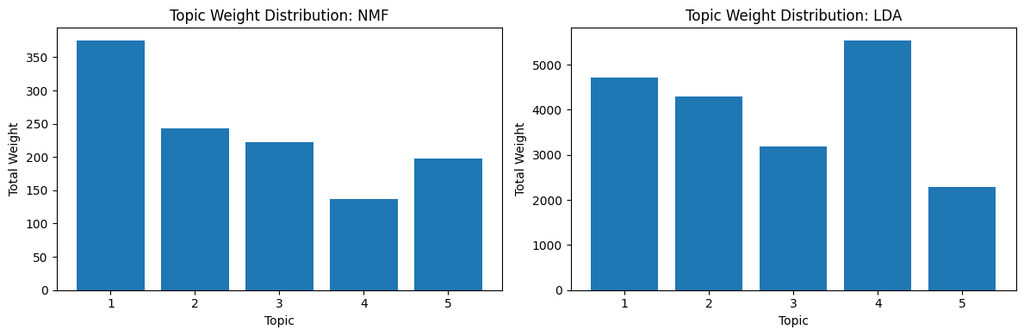

```python
fig, axes = plt.subplots(1, 2, figsize=(12, 4))

axes[0].bar(range(1, num_topics+1), X_nmf.sum(axis=0))
axes[0].set_title("Topic Weight Distribution: NMF")
axes[0].set_xlabel("Topic"); axes[0].set_ylabel("Total Weight")

axes[1].bar(range(1, num_topics+1), X_lda.sum(axis=0))
axes[1].set_title("Topic Weight Distribution: LDA")
axes[1].set_xlabel("Topic"); axes[1].set_ylabel("Total Weight")

plt.tight_layout()
plt.show()
```

## Part 6: What do customers care about, and how do they feel about it?

Finding topics is only half the job. The dataset also has a 1-5 star rating for every review, so I can connect the two: assign each review to its strongest NMF topic, then look at how big each topic is and how customers rate it. That turns "here are five word clusters" into "here's what customers talk about most and where the complaints are."

```python
# Assign each review to its dominant NMF topic
df['topic'] = X_nmf.argmax(axis=1) + 1

# Short label for each topic from its top 3 words
topic_labels = {}
for i, topic in enumerate(nmf.components_):
    top3 = [svd_vocab[j] for j in topic.argsort()[:-4:-1]]
    topic_labels[i + 1] = ' / '.join(top3)

summary = df.groupby('topic').agg(
    n_reviews=('Score', 'size'),
    avg_rating=('Score', 'mean'),
    pct_negative=('Score', lambda s: (s <= 2).mean() * 100)
).round(2)
summary['share_of_reviews'] = (summary['n_reviews'] / len(df) * 100).round(1)
summary.index = [f"Topic {i}: {topic_labels[i]}" for i in summary.index]

summary = summary[['n_reviews', 'share_of_reviews', 'avg_rating', 'pct_negative']]
print(summary.to_string())
```

```
                                 n_reviews  share_of_reviews  avg_rating  pct_negative
Topic 1: great / product / good      10291              51.5        4.22         14.04
Topic 2: coffee / cup / cups          3215              16.1        4.14         13.31
Topic 3: drink / juice / sugar        2382              11.9        3.81         20.03
Topic 4: tea / teas / grey            1322               6.6        4.35         10.82
Topic 5: dog / treats / food          2790              14.0        4.17         16.16
```

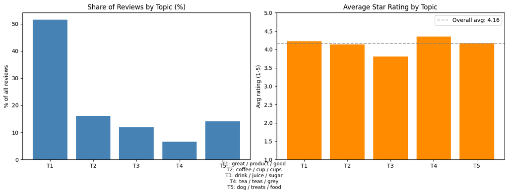

```python
fig, axes = plt.subplots(1, 2, figsize=(13, 4.5))

labels = [f"T{i+1}" for i in range(len(summary))]

axes[0].bar(labels, summary['share_of_reviews'], color='steelblue')
axes[0].set_title('Share of Reviews by Topic (%)')
axes[0].set_ylabel('% of all reviews')

axes[1].bar(labels, summary['avg_rating'], color='darkorange')
axes[1].axhline(y=df['Score'].mean(), color='gray', linestyle='--', alpha=0.7,
                label=f"Overall avg: {df['Score'].mean():.2f}")
axes[1].set_title('Average Star Rating by Topic')
axes[1].set_ylabel('Avg rating (1-5)')
axes[1].set_ylim(1, 5)
axes[1].legend()

legend_text = '\n'.join(f"T{i}: {topic_labels[i]}" for i in topic_labels)
fig.text(0.5, -0.08, legend_text, ha='center', fontsize=9)

plt.tight_layout()
plt.show()
```

In this sample, coffee is the largest product category at about 16% of reviews, drinks like juice and soda draw the most complaints (3.81 average rating, with 20% of their reviews at 1-2 stars), and tea is rated most positively at 4.35. Over half of all reviews land in a generic praise topic (great, product, good), which is a known quirk of review data: most people who bother to write are happy, and their language isn't product-specific. This is the kind of output a product or marketing team could actually act on, like digging into why drink reviews skew negative.

## Takeaways

- 20,000 unlabeled reviews reduce to a handful of clear product categories: coffee, tea, pet food, and drinks/snacks
- NMF produced the most interpretable topics; SVD had themes bleeding into each other and LDA let high-frequency filler words dominate
- Linking topics to star ratings shows which categories customers discuss most and where negative reviews concentrate, which is what makes this useful beyond the model itself
- Preprocessing mattered as much as the model. Dropping short tokens removed leftover `<br>` HTML fragments that otherwise formed a junk topic
- Explained variance is a misleading quality metric for text. Components with under 1% variance were still perfectly readable